# S-SOMAS Pilot-0 CFA and IRT

Douglas Whitaker

01 November 2021

## CFA

This draws on Matt’s code for reading the data and the like.

# Reading in the Data

We read in the datasets created using the `pilot0_data_cleaning.Rmd` file.

We now drop the “nrc” columns because we won’t use them.

Now we’ll do some basic checking of normality assumptions. We expect the data to not follow a normal distribution, but the hope is that it does not deviate too terribly from normality as to compromise the subsequent analyses.

```
## [1] 1.344408
```

```
## [1] 2.777551
```

```
## [1] 2.769337
```

```
## [1] 10.04459
```

According to Kline (2005), “absolute skew greater than 3 and kurtosis greater than 10 are problematic.” Only a single item is problematic: AcadSC_1 (ASC1; “44- Doing well in school is important to me.”). This item was noted as being problematic for several reasons: - It seems to be measuring Attainment Value, not Academic Self-Concept (based on alignment to construct definitions). - Even if it were an Attainment Value item, it is quite general. - In the Summer 2020 EFA, it loaded in the empirical Attainment Value construct. - There is a substantial ceiling effect.

With those noted problems, we will exclude this item from the subsequent analyses. Otherwise, despite the obvious non-normality of the data from each item, we will proceed with the CFA.

# Confirmatory Factor Analysis

## CFA Reminders

Note: This section copies and builds on Alana’s prose and code.

Ideal metrics:

- CFI >= 0.95
- RMSEA <= 0.05, upper 90$ CI <= 0.10
- SRMR <= 0.08

Since all variables being assessed are ordinal, we tell R to use weighted least squares instead of maximum likelihood estimation by using the option `ordered=names()` in the `cfa()` statement. This also defaults to using polychoric correlations. For fit parameters, use the ‘’robust’’ estimates as justified by the `lavaan` package authors. This method uses ‘’diagonally weighted least squares (DWLS) for estimation, and a scaled-shifted test statistic (SS).’’ Other books refer to this as robust diagonally weighted least squares.(Can cite Brown CFA book, or R books as reference here.)

## List of Models

| Name | Group | Factors |
| --- | --- | --- |
| Model 1.1 | Group 1 | 6 |

## Model 1.1

```
##            cfi.scaled            tli.scaled          rmsea.scaled
##                 0.824                 0.814                 0.101
## rmsea.ci.upper.scaled                  srmr
##                 0.102                 0.082
```

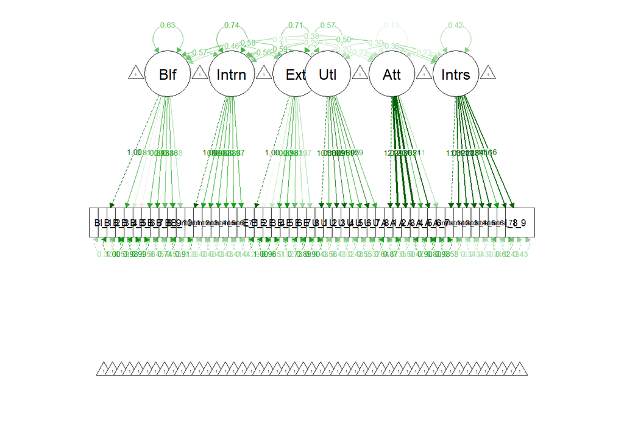

```
## For constructs with categorical indicators, the alpha and the average variance extracted are calculated from polychoric (polyserial) correlations, not from Pearson correlations.
```

```
##           Belief Intrinsic Extrinsic   Utility Attainment  Interest
## alpha  0.6893208 0.9111031 0.7631661 0.8913051  0.7149929 0.9307365
## omega  0.7205882 0.9017694 0.6878441 0.8832909  0.7043226 0.9246075
## omega2 0.7205882 0.9017694 0.6878441 0.8832909  0.7043226 0.9246075
## omega3 0.7414618 0.9117106 0.5706527 0.9029988  0.6751769 0.9318355
## avevar 0.2879280 0.6026480 0.2999824 0.5274126  0.3050275 0.6148099
```

```
##          chisq.scaled             df.scaled            cfi.scaled
##             14342.148              1112.000                 0.824
##            tli.scaled                  srmr          rmsea.scaled
##                 0.814                 0.082                 0.101
## rmsea.ci.upper.scaled
##                 0.102
```

Now we need to identify local misfit by examining the covariance matrix. We’ll write it to a CSV and examine it manually.

```
##              lhs  op          rhs    est    se       z pvalue ci.lower ci.upper
## 1         Belief  =~     Belief_1  1.000 0.000      NA     NA    1.000    1.000
## 2         Belief  =~   Belief_2rc -0.026 0.036  -0.720  0.471   -0.097    0.045
## 3         Belief  =~   Belief_3rc  0.810 0.026  30.998  0.000    0.759    0.862
## 4         Belief  =~   Belief_4rc  0.177 0.036   4.978  0.000    0.107    0.247
## 5         Belief  =~   Belief_5rc -0.093 0.037  -2.528  0.011   -0.165   -0.021
## 6         Belief  =~     Belief_6  0.836 0.024  35.220  0.000    0.790    0.883
## 7         Belief  =~     Belief_7  0.930 0.025  37.805  0.000    0.882    0.978
## 8         Belief  =~     Belief_8  0.642 0.031  20.751  0.000    0.581    0.702
## 9         Belief  =~     Belief_9  0.861 0.023  37.829  0.000    0.816    0.905
## 10        Belief  =~  Belief_10rc  0.385 0.035  11.086  0.000    0.317    0.453
## 11     Intrinsic  =~  Intrinsic_1  1.000 0.000      NA     NA    1.000    1.000
## 12     Intrinsic  =~  Intrinsic_2  0.900 0.014  63.528  0.000    0.872    0.927
## 13     Intrinsic  =~  Intrinsic_3  0.902 0.015  59.917  0.000    0.872    0.931
## 14     Intrinsic  =~  Intrinsic_4  0.882 0.016  56.772  0.000    0.852    0.913
```

[output cut: 503 more lines]

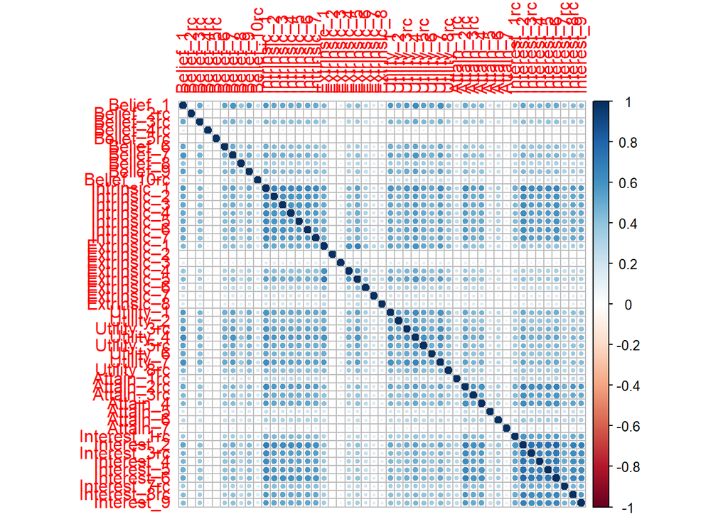

## Model 2.1

```
##            cfi.scaled            tli.scaled          rmsea.scaled
##                 0.791                 0.779                 0.092
## rmsea.ci.upper.scaled                  srmr
##                 0.093                 0.087
```

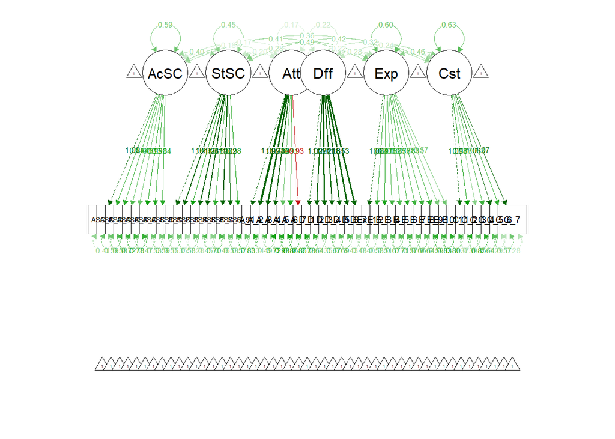

```
## For constructs with categorical indicators, the alpha and the average variance extracted are calculated from polychoric (polyserial) correlations, not from Pearson correlations.
```

```
##           AcadSC    StatSC Attainmenet Difficulty Expectancy      Cost
## alpha  0.8388171 0.8922815   0.6828691  0.8204529  0.8603720 0.8618332
## omega  0.8225640 0.8877697   0.5811680  0.8177102  0.8420565 0.8674700
## omega2 0.8225640 0.8877697   0.5811680  0.8177102  0.8420565 0.8674700
## omega3 0.8560465 0.9056068   0.4300173  0.8388849  0.8477211 0.9013292
## avevar 0.4165508 0.5025937   0.2798787  0.4227547  0.3669947 0.5146909
```

```
##          chisq.scaled             df.scaled            cfi.scaled
##             12077.752              1112.000                 0.791
##            tli.scaled                  srmr          rmsea.scaled
##                 0.779                 0.087                 0.092
## rmsea.ci.upper.scaled
##                 0.093
```

Now we need to identify local misfit by examining the covariance matrix. We’ll write it to a CSV and examine it manually.

```
##                 lhs  op             rhs    est    se       z pvalue ci.lower
## 1            AcadSC  =~        AcadSC_2  1.000 0.000      NA     NA    1.000
## 2            AcadSC  =~        AcadSC_3  0.839 0.032  25.916  0.000    0.775
## 3            AcadSC  =~        AcadSC_4  0.844 0.030  28.515  0.000    0.786
## 4            AcadSC  =~      AcadSC_5rc  0.687 0.035  19.479  0.000    0.618
## 5            AcadSC  =~        AcadSC_6  0.606 0.038  16.097  0.000    0.532
## 6            AcadSC  =~      AcadSC_7rc  0.949 0.032  30.103  0.000    0.887
## 7            AcadSC  =~      AcadSC_8rc  0.898 0.034  26.257  0.000    0.831
## 8            AcadSC  =~      AcadSC_9rc  0.838 0.034  24.889  0.000    0.772
## 9            StatSC  =~        StatSC_1  1.000 0.000      NA     NA    1.000
## 10           StatSC  =~        StatSC_2  1.199 0.028  42.771  0.000    1.144
## 11           StatSC  =~        StatSC_3  0.960 0.029  32.669  0.000    0.903
## 12           StatSC  =~      StatSC_4rc  1.261 0.030  41.586  0.000    1.202
## 13           StatSC  =~      StatSC_5rc  1.105 0.030  36.429  0.000    1.046
## 14           StatSC  =~        StatSC_6  0.821 0.032  26.009  0.000    0.759
```

[output cut: 1021 more lines]

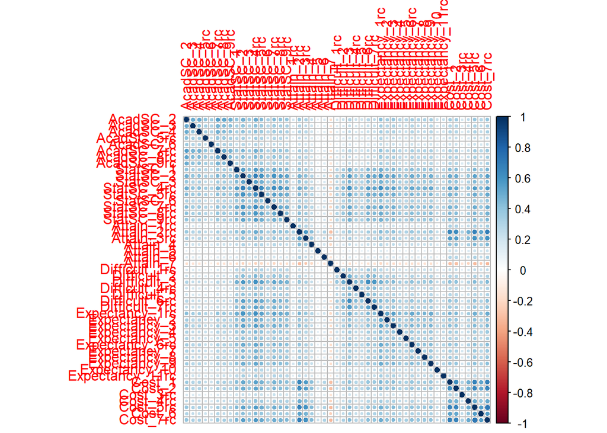